# Pandas-Bootcamp-Part9

### Reshaping with Pivots

- Building Pivot tables from first principles
- the pivot() and pivot_table() constructs
- MultiIndex Pivot tables
- Applying Multiple function
- Pivot Customization with Margins

#### In this section we are going to Analyze the SAT Scores of High Schools

New Data : New York City SAT Scores https://andybek.com/pandas-sat

```python
import pandas as pd
import numpy as np
```

```python
sat = pd.read_csv('scores.csv')
```

```python
sat.head(3)
```

|  | School Name | Borough | Student Enrollment | Percent Tested | SAT Section | Score |
| --- | --- | --- | --- | --- | --- | --- |
| 0 | A. Philip Randolph Campus High School | Manhattan | 1354 | 74.0 | Math | 459 |
| 1 | A. Philip Randolph Campus High School | Manhattan | 1354 | 74.0 | Reading | 453 |
| 2 | A. Philip Randolph Campus High School | Manhattan | 1354 | 74.0 | Writing | 447 |

- SAT is the most poupular entrance exam in the US. It is a Standardized text that is administered by an organization called the "CollegeBoard" in Colleges and universities across the US and also Internationally for the Admission Process.

In this section we are going to be working with a Subset of data that captures the SAT scores from the New York City High schools.

The dept. of Education in the US collects data from high schools across the Country and in this section we will be focussing on a small Sub-set of that Data.(specifically NYC)

```python
sat.info()
```

```
<class 'pandas.core.frame.DataFrame'>
RangeIndex: 1125 entries, 0 to 1124
Data columns (total 6 columns):
 #   Column              Non-Null Count  Dtype
---  ------              --------------  -----
 0   School Name         1125 non-null   object
 1   Borough             1125 non-null   object
 2   Student Enrollment  1125 non-null   int64
 3   Percent Tested      1125 non-null   object
 4   SAT Section         1125 non-null   object
 5   Score               1125 non-null   int64
dtypes: int64(2), object(4)
memory usage: 52.9+ KB
```

- The dataframe has 6 columns : 2 of which are Numeric : "Student Enrollment" and "Score"
- "Percent Tested" is also supposed to be Numeric . But because of the "%" sign here , its passed as an Object
- Which is not very memory efficient
- We can go ahead and replace it

```python
sat.columns
```

```
Index(['School Name', 'Borough', 'Student Enrollment', 'Percent Tested',
       'SAT Section', 'Score'],
      dtype='object')
```

```python
#We replace % with regex and cast the remaining value to "Float"
sat['Percent Tested'].replace(regex = '%' , value = '').astype(float)
```

```
0        74.0
1        74.0
2        74.0
3        54.9
4        54.9
        ...
1120    100.0
1121    100.0
1122     90.4
1123     90.4
1124     90.4
Name: Percent Tested, Length: 1125, dtype: float64
```

### OR

```python
sat['Percent Tested'].str.replace('%' , '').astype(float)
```

```
0        74.0
1        74.0
2        74.0
3        54.9
4        54.9
        ...
1120    100.0
1121    100.0
1122     90.4
1123     90.4
1124     90.4
Name: Percent Tested, Length: 1125, dtype: float64
```

```python
sat['Percent Tested'] = sat['Percent Tested'].str.replace('%' , '').astype(float)
```

### Pivoting Table

Pivoting is all about Reshaping data

- We take a DataFrame or Series without changing or modifying the content we present it differently.

For each School , the three sections of the Exam : "Math" , "Reading" and "Writing" are represented in separate records or Rows.

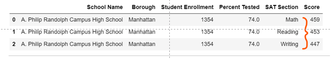

Because of this , certain attribute values are getting repeated , like : "Percent Tested" or the "Student Enrollment" or the "Borough". All of these attributes are repeating within Schools and differ across Schools .

So, we can reasonably argue that this is not the most sensible way to present data.

To avoid this unnecessary duplication in school specific attributes , we might be interested in changing the structure of the DataFrame to the Column axis separately

```python
#create a MultiIndex of 'School Name' and 'SAT Section'
#Then we index for the "SCore"
#And finally we can transfer the inner level of our "SAT Section" over to the column axis
```

```python
sat.columns
```

```
Index(['School Name', 'Borough', 'Student Enrollment', 'Percent Tested',
       'SAT Section', 'Score'],
      dtype='object')
```

```python
sat.set_index(['School Name','SAT Section'])
```

| School Name | SAT Section | Borough | Student Enrollment | Percent Tested | Score |
| --- | --- | --- | --- | --- | --- |
| A. Philip Randolph Campus High School | Math | Manhattan | 1354 | 74.0 | 459 |
|  | Reading | Manhattan | 1354 | 74.0 | 453 |
|  | Writing | Manhattan | 1354 | 74.0 | 447 |
| Abraham Lincoln High School | Math | Brooklyn | 2341 | 54.9 | 441 |
|  | Reading | Brooklyn | 2341 | 54.9 | 422 |
| ... | ... | ... | ... | ... | ... |
| Young Women's Leadership School in Astoria | Reading | Queens | 572 | 100.0 | 464 |
|  | Writing | Queens | 572 | 100.0 | 477 |
| Young Women's Leadership School in Queens | Math | Queens | 557 | 90.4 | 415 |
|  | Reading | Queens | 557 | 90.4 | 420 |
|  | Writing | Queens | 557 | 90.4 | 433 |

1125 rows × 4 columns

```python
sat.set_index(['School Name','SAT Section']).loc[: , ['Score']]
```

| School Name | SAT Section | Score |
| --- | --- | --- |
| A. Philip Randolph Campus High School | Math | 459 |
|  | Reading | 453 |
|  | Writing | 447 |
| Abraham Lincoln High School | Math | 441 |
|  | Reading | 422 |
| ... | ... | ... |
| Young Women's Leadership School in Astoria | Reading | 464 |
|  | Writing | 477 |
| Young Women's Leadership School in Queens | Math | 415 |
|  | Reading | 420 |
|  | Writing | 433 |

1125 rows × 1 columns

```python
#And finally we can transfer the inner level of our "SAT Section" over to the column axis
#We can simply call the method : unstack()
sat.set_index(['School Name','SAT Section']).loc[: , ['Score']].unstack(level = 1)
```

| SAT Section School Name | Score Math | Score Reading | Score Writing |
| --- | --- | --- | --- |
| A. Philip Randolph Campus High School | 459 | 453 | 447 |
| ACORN Community High School | 379 | 395 | 385 |
| Abraham Lincoln High School | 441 | 422 | 422 |
| Academy for Careers in Television and Film | 444 | 458 | 444 |
| Academy for College Preparation and Career Exploration (College Board) | 386 | 397 | 393 |
| ... | ... | ... | ... |
| World Journalism Preparatory (College Board) | 484 | 491 | 487 |
| York Early College Academy | 496 | 481 | 473 |
| Young Women's Leadership School | 478 | 465 | 472 |
| Young Women's Leadership School in Astoria | 483 | 464 | 477 |
| Young Women's Leadership School in Queens | 415 | 420 | 433 |

375 rows × 3 columns

This looks organized , but notice the many steps that we had to perform to get to this step.

- This kind of Reshaping work is widely needed in Data Analysis

#### Pivot table

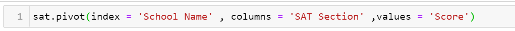

We can replicate the above view using **pivot()** method

```python
sat.head()
```

|  | School Name | Borough | Student Enrollment | Percent Tested | SAT Section | Score |
| --- | --- | --- | --- | --- | --- | --- |
| 0 | A. Philip Randolph Campus High School | Manhattan | 1354 | 74.0 | Math | 459 |
| 1 | A. Philip Randolph Campus High School | Manhattan | 1354 | 74.0 | Reading | 453 |
| 2 | A. Philip Randolph Campus High School | Manhattan | 1354 | 74.0 | Writing | 447 |
| 3 | Abraham Lincoln High School | Brooklyn | 2341 | 54.9 | Math | 441 |
| 4 | Abraham Lincoln High School | Brooklyn | 2341 | 54.9 | Reading | 422 |

```python
sat.pivot('School Name' , 'SAT Section' , 'Score')
```

| SAT Section School Name | Math | Reading | Writing |
| --- | --- | --- | --- |
| A. Philip Randolph Campus High School | 459 | 453 | 447 |
| ACORN Community High School | 379 | 395 | 385 |
| Abraham Lincoln High School | 441 | 422 | 422 |
| Academy for Careers in Television and Film | 444 | 458 | 444 |
| Academy for College Preparation and Career Exploration (College Board) | 386 | 397 | 393 |
| ... | ... | ... | ... |
| World Journalism Preparatory (College Board) | 484 | 491 | 487 |
| York Early College Academy | 496 | 481 | 473 |
| Young Women's Leadership School | 478 | 465 | 472 |
| Young Women's Leadership School in Astoria | 483 | 464 | 477 |
| Young Women's Leadership School in Queens | 415 | 420 | 433 |

375 rows × 3 columns

```python
sat.pivot('School Name' , 'Borough'  , 'Percent Tested' )
```

[output not shown]

```python
sat.pivot(index = 'School Name' , columns = 'SAT Section' ,values = 'Score')
```

| SAT Section School Name | Math | Reading | Writing |
| --- | --- | --- | --- |
| A. Philip Randolph Campus High School | 459 | 453 | 447 |
| ACORN Community High School | 379 | 395 | 385 |
| Abraham Lincoln High School | 441 | 422 | 422 |
| Academy for Careers in Television and Film | 444 | 458 | 444 |
| Academy for College Preparation and Career Exploration (College Board) | 386 | 397 | 393 |
| ... | ... | ... | ... |
| World Journalism Preparatory (College Board) | 484 | 491 | 487 |
| York Early College Academy | 496 | 481 | 473 |
| Young Women's Leadership School | 478 | 465 | 472 |
| Young Women's Leadership School in Astoria | 483 | 464 | 477 |
| Young Women's Leadership School in Queens | 415 | 420 | 433 |

375 rows × 3 columns

```python
pivoted = sat.pivot(index = 'School Name' , columns = 'SAT Section' ,values = 'Score')
```

```python
pivoted.head(4)
```

| SAT Section School Name | Math | Reading | Writing |
| --- | --- | --- | --- |
| A. Philip Randolph Campus High School | 459 | 453 | 447 |
| ACORN Community High School | 379 | 395 | 385 |
| Abraham Lincoln High School | 441 | 422 | 422 |
| Academy for Careers in Television and Film | 444 | 458 | 444 |

### How do you undo a Pivot

**This is a Cheat** : One way is to simply assign different pivoted views of the data to separate variables and so if we need to return to the previous view , we simply call those variables.

#### Bring MultiColumn SAT_Section back to single column

```python
pivoted.head(3)
```

| SAT Section School Name | Math | Reading | Writing |
| --- | --- | --- | --- |
| A. Philip Randolph Campus High School | 459 | 453 | 447 |
| ACORN Community High School | 379 | 395 | 385 |
| Abraham Lincoln High School | 441 | 422 | 422 |

```python
pivoted.columns
```

```
Index(['Math', 'Reading', 'Writing'], dtype='object', name='SAT Section')
```

### we use stack()

stack() takes the column axis and rotates it clockwise into the rightmost level of the Index axis.

- In other words , it takes a wide dataset and it makes it longer and narrower

```python
pivoted
```

| SAT Section School Name | Math | Reading | Writing |
| --- | --- | --- | --- |
| A. Philip Randolph Campus High School | 459 | 453 | 447 |
| ACORN Community High School | 379 | 395 | 385 |
| Abraham Lincoln High School | 441 | 422 | 422 |
| Academy for Careers in Television and Film | 444 | 458 | 444 |
| Academy for College Preparation and Career Exploration (College Board) | 386 | 397 | 393 |
| ... | ... | ... | ... |
| World Journalism Preparatory (College Board) | 484 | 491 | 487 |
| York Early College Academy | 496 | 481 | 473 |
| Young Women's Leadership School | 478 | 465 | 472 |
| Young Women's Leadership School in Astoria | 483 | 464 | 477 |
| Young Women's Leadership School in Queens | 415 | 420 | 433 |

375 rows × 3 columns

```python
pivoted.stack().head(10)
```

```
School Name                                 SAT Section
A. Philip Randolph Campus High School       Math           459
                                            Reading        453
                                            Writing        447
ACORN Community High School                 Math           379
                                            Reading        395
                                            Writing        385
Abraham Lincoln High School                 Math           441
                                            Reading        422
                                            Writing        422
Academy for Careers in Television and Film  Math           444
dtype: int64
```

```python
type(pivoted.stack())
```

```
pandas.core.series.Series
```

```python
pd.DataFrame(pivoted.stack())
```

| School Name | SAT Section | 0 |
| --- | --- | --- |
| A. Philip Randolph Campus High School | Math | 459 |
|  | Reading | 453 |
|  | Writing | 447 |
| ACORN Community High School | Math | 379 |
|  | Reading | 395 |
| ... | ... | ... |
| Young Women's Leadership School in Astoria | Reading | 464 |
|  | Writing | 477 |
| Young Women's Leadership School in Queens | Math | 415 |
|  | Reading | 420 |
|  | Writing | 433 |

1125 rows × 1 columns

```python
type(pd.DataFrame(pivoted.stack()))
```

```
pandas.core.frame.DataFrame
```

```python
#Now we have  a multiIndex Series
```

```python
pivoted.stack().index
```

```
MultiIndex([(     'A. Philip Randolph Campus High School',    'Math'),
            (     'A. Philip Randolph Campus High School', 'Reading'),
            (     'A. Philip Randolph Campus High School', 'Writing'),
            (               'ACORN Community High School',    'Math'),
            (               'ACORN Community High School', 'Reading'),
            (               'ACORN Community High School', 'Writing'),
            (               'Abraham Lincoln High School',    'Math'),
            (               'Abraham Lincoln High School', 'Reading'),
            (               'Abraham Lincoln High School', 'Writing'),
            ('Academy for Careers in Television and Film',    'Math'),
            ...
            (                'York Early College Academy', 'Writing'),
            (           'Young Women's Leadership School',    'Math'),
            (           'Young Women's Leadership School', 'Reading'),
            (           'Young Women's Leadership School', 'Writing'),
            ('Young Women's Leadership School in Astoria',    'Math'),
            ('Young Women's Leadership School in Astoria', 'Reading'),
            ('Young Women's Leadership School in Astoria', 'Writing'),
            ( 'Young Women's Leadership School in Queens',    'Math'),
            ( 'Young Women's Leadership School in Queens', 'Reading'),
            ( 'Young Women's Leadership School in Queens', 'Writing')],
           names=['School Name', 'SAT Section'], length=1125)
```

```python
#To revert back to our Flat dataframe , we can chain on a reset_index()
```

```python
pivoted.stack().reset_index()
```

|  | School Name | SAT Section | 0 |
| --- | --- | --- | --- |
| 0 | A. Philip Randolph Campus High School | Math | 459 |
| 1 | A. Philip Randolph Campus High School | Reading | 453 |
| 2 | A. Philip Randolph Campus High School | Writing | 447 |
| 3 | ACORN Community High School | Math | 379 |
| 4 | ACORN Community High School | Reading | 395 |
| ... | ... | ... | ... |
| 1120 | Young Women's Leadership School in Astoria | Reading | 464 |
| 1121 | Young Women's Leadership School in Astoria | Writing | 477 |
| 1122 | Young Women's Leadership School in Queens | Math | 415 |
| 1123 | Young Women's Leadership School in Queens | Reading | 420 |
| 1124 | Young Women's Leadership School in Queens | Writing | 433 |

1125 rows × 3 columns

### melt()

melt() is used to change the dataframe to a structure where the so called "measure" variables are unpivoted to the row axis.

```python
pivoted.head(4)
```

| SAT Section School Name | Math | Reading | Writing |
| --- | --- | --- | --- |
| A. Philip Randolph Campus High School | 459 | 453 | 447 |
| ACORN Community High School | 379 | 395 | 385 |
| Abraham Lincoln High School | 441 | 422 | 422 |
| Academy for Careers in Television and Film | 444 | 458 | 444 |

#### Whats happening in melt()

- SAT_Section our only "Measure" or "Numeric" variable has been unpivoted and each individual record is associated with a single value
- Notice how we also lost our 'School Names' in the process.
- The reason that happened because "School_Name" is in our Index

```python
pivoted.melt()
```

|  | SAT Section | value |
| --- | --- | --- |
| 0 | Math | 459 |
| 1 | Math | 379 |
| 2 | Math | 441 |
| 3 | Math | 444 |
| 4 | Math | 386 |
| ... | ... | ... |
| 1120 | Writing | 487 |
| 1121 | Writing | 473 |
| 1122 | Writing | 472 |
| 1123 | Writing | 477 |
| 1124 | Writing | 433 |

1125 rows × 2 columns

- If we want to have "'School Names" in the view
- we have to reset_index()
- then we apply melt()

```python
pivoted.reset_index().melt()
```

|  | SAT Section | value |
| --- | --- | --- |
| 0 | School Name | A. Philip Randolph Campus High School |
| 1 | School Name | ACORN Community High School |
| 2 | School Name | Abraham Lincoln High School |
| 3 | School Name | Academy for Careers in Television and Film |
| 4 | School Name | Academy for College Preparation and Career Exp... |
| ... | ... | ... |
| 1495 | Writing | 487 |
| 1496 | Writing | 473 |
| 1497 | Writing | 472 |
| 1498 | Writing | 477 |
| 1499 | Writing | 433 |

1500 rows × 2 columns

- But we still don't see a clear output
- we have a slight problem here
- The 'School Name' is a Categorical variable and it is also stacked
- Infact it should be treated as a Identifier variable.
- We can keep the "School Name" variable from unpivoting

### melt() : Parameter : (id_vars)

- We assign "School Name" to the "id_vars" parameter
- That means this variable should be kept as it is and not include in the melt process

```python
pivoted.head()
```

| SAT Section School Name | Math | Reading | Writing |
| --- | --- | --- | --- |
| A. Philip Randolph Campus High School | 459 | 453 | 447 |
| ACORN Community High School | 379 | 395 | 385 |
| Abraham Lincoln High School | 441 | 422 | 422 |
| Academy for Careers in Television and Film | 444 | 458 | 444 |
| Academy for College Preparation and Career Exploration (College Board) | 386 | 397 | 393 |

```python
pivoted.reset_index().melt(id_vars = 'School Name')
```

|  | School Name | SAT Section | value |
| --- | --- | --- | --- |
| 0 | A. Philip Randolph Campus High School | Math | 459 |
| 1 | ACORN Community High School | Math | 379 |
| 2 | Abraham Lincoln High School | Math | 441 |
| 3 | Academy for Careers in Television and Film | Math | 444 |
| 4 | Academy for College Preparation and Career Exp... | Math | 386 |
| ... | ... | ... | ... |
| 1120 | World Journalism Preparatory (College Board) | Writing | 487 |
| 1121 | York Early College Academy | Writing | 473 |
| 1122 | Young Women's Leadership School | Writing | 472 |
| 1123 | Young Women's Leadership School in Astoria | Writing | 477 |
| 1124 | Young Women's Leadership School in Queens | Writing | 433 |

1125 rows × 3 columns

```python
sat.head()
```

|  | School Name | Borough | Student Enrollment | Percent Tested | SAT Section | Score |
| --- | --- | --- | --- | --- | --- | --- |
| 0 | A. Philip Randolph Campus High School | Manhattan | 1354 | 74.0 | Math | 459 |
| 1 | A. Philip Randolph Campus High School | Manhattan | 1354 | 74.0 | Reading | 453 |
| 2 | A. Philip Randolph Campus High School | Manhattan | 1354 | 74.0 | Writing | 447 |
| 3 | Abraham Lincoln High School | Brooklyn | 2341 | 54.9 | Math | 441 |
| 4 | Abraham Lincoln High School | Brooklyn | 2341 | 54.9 | Reading | 422 |

#### Be careful when using the melt()

- The two numeric columns "Percent Tested" and "Score" has been included in the melt()
- If we want to include just one particular columnb in melt then its better to slice it before hand

```python
sat.melt(id_vars = ['School Name','Borough', 'Student Enrollment', 'SAT Section'] )
```

|  | School Name | Borough | Student Enrollment | SAT Section | variable | value |
| --- | --- | --- | --- | --- | --- | --- |
| 0 | A. Philip Randolph Campus High School | Manhattan | 1354 | Math | Percent Tested | 74.0 |
| 1 | A. Philip Randolph Campus High School | Manhattan | 1354 | Reading | Percent Tested | 74.0 |
| 2 | A. Philip Randolph Campus High School | Manhattan | 1354 | Writing | Percent Tested | 74.0 |
| 3 | Abraham Lincoln High School | Brooklyn | 2341 | Math | Percent Tested | 54.9 |
| 4 | Abraham Lincoln High School | Brooklyn | 2341 | Reading | Percent Tested | 54.9 |
| ... | ... | ... | ... | ... | ... | ... |
| 2245 | Young Women's Leadership School in Astoria | Queens | 572 | Reading | Score | 464.0 |
| 2246 | Young Women's Leadership School in Astoria | Queens | 572 | Writing | Score | 477.0 |
| 2247 | Young Women's Leadership School in Queens | Queens | 557 | Math | Score | 415.0 |
| 2248 | Young Women's Leadership School in Queens | Queens | 557 | Reading | Score | 420.0 |
| 2249 | Young Women's Leadership School in Queens | Queens | 557 | Writing | Score | 433.0 |

2250 rows × 6 columns

#### Lets slice the dataframe and then pass it to the melt()

```python
sat.head()
```

|  | School Name | Borough | Student Enrollment | Percent Tested | SAT Section | Score |
| --- | --- | --- | --- | --- | --- | --- |
| 0 | A. Philip Randolph Campus High School | Manhattan | 1354 | 74.0 | Math | 459 |
| 1 | A. Philip Randolph Campus High School | Manhattan | 1354 | 74.0 | Reading | 453 |
| 2 | A. Philip Randolph Campus High School | Manhattan | 1354 | 74.0 | Writing | 447 |
| 3 | Abraham Lincoln High School | Brooklyn | 2341 | 54.9 | Math | 441 |
| 4 | Abraham Lincoln High School | Brooklyn | 2341 | 54.9 | Reading | 422 |

```python
sat.columns
```

```
Index(['School Name', 'Borough', 'Student Enrollment', 'Percent Tested',
       'SAT Section', 'Score'],
      dtype='object')
```

```python
sat2 = sat[['School Name', 'Borough', 'Student Enrollment',
       'SAT Section', 'Score']]
```

```python
#id_vars = ['School Name', 'Borough', 'Student Enrollment','SAT Section'] , are the columns we do not want to melt
# 'Score' : we want to melt
#The new column thats created is being  named 'melted_Score'
```

```python
sat2.melt(id_vars = ['School Name', 'Borough', 'Student Enrollment','SAT Section'] , value_name = 'melted_Score')
```

|  | School Name | Borough | Student Enrollment | SAT Section | variable | melted_Score |
| --- | --- | --- | --- | --- | --- | --- |
| 0 | A. Philip Randolph Campus High School | Manhattan | 1354 | Math | Score | 459 |
| 1 | A. Philip Randolph Campus High School | Manhattan | 1354 | Reading | Score | 453 |
| 2 | A. Philip Randolph Campus High School | Manhattan | 1354 | Writing | Score | 447 |
| 3 | Abraham Lincoln High School | Brooklyn | 2341 | Math | Score | 441 |
| 4 | Abraham Lincoln High School | Brooklyn | 2341 | Reading | Score | 422 |
| ... | ... | ... | ... | ... | ... | ... |
| 1120 | Young Women's Leadership School in Astoria | Queens | 572 | Reading | Score | 464 |
| 1121 | Young Women's Leadership School in Astoria | Queens | 572 | Writing | Score | 477 |
| 1122 | Young Women's Leadership School in Queens | Queens | 557 | Math | Score | 415 |
| 1123 | Young Women's Leadership School in Queens | Queens | 557 | Reading | Score | 420 |
| 1124 | Young Women's Leadership School in Queens | Queens | 557 | Writing | Score | 433 |

1125 rows × 6 columns

### What about Aggregates ?

#### We are interested in getting some insight on the Average SAT Scores by Borough

```python
sat.head(3)
```

|  | School Name | Borough | Student Enrollment | Percent Tested | SAT Section | Score |
| --- | --- | --- | --- | --- | --- | --- |
| 0 | A. Philip Randolph Campus High School | Manhattan | 1354 | 74.0 | Math | 459 |
| 1 | A. Philip Randolph Campus High School | Manhattan | 1354 | 74.0 | Reading | 453 |
| 2 | A. Philip Randolph Campus High School | Manhattan | 1354 | 74.0 | Writing | 447 |

```python
#Checking the unique Boroughs
sat.Borough.unique()
```

```
array(['Manhattan', 'Brooklyn', 'Queens', 'Bronx', 'Staten Island'],
      dtype=object)
```

#### We want to Reshape our DataFrame to show SAT scores by Borough

#### What is the Average SAT Score by Borough

- One approach might be to Pivot our data in such a way that Borough is acting as the "index"
- and "SAT Section" is in the 'Columns'
- the 'Score' column become 'values'

```python
 sat.pivot(index = 'Borough' , columns = 'SAT Section' , values = 'Score')
```

[output not shown]

Pandas throws a Value Error here indicatin that the Index contains Duplicate entries. Meaning the Index values will not be Unique. Because each Borough has many schools .If we only use Borough in the index , we will have several repeating records.

As we mentioned before , Indices in Pandas could certainly contain Duplicate Values

But the point is :

#### Pandas allows Duplicates in the Index of a regular DataFrame

However , the Index provided to the Pivot method cannot contain Duplicate Values.

- Notice that , in the main DataFrame "School Name" also has repeated values
- If we unstack the "SAT Section" or pivot it to the "column axis" , "School Name" all of a sudden becomes unique , but if we do the same with "Borough" still doesn't become unique because each "Borough" has several schools.

```python
sat.head(4)
```

|  | School Name | Borough | Student Enrollment | Percent Tested | SAT Section | Score |
| --- | --- | --- | --- | --- | --- | --- |
| 0 | A. Philip Randolph Campus High School | Manhattan | 1354 | 74.0 | Math | 459 |
| 1 | A. Philip Randolph Campus High School | Manhattan | 1354 | 74.0 | Reading | 453 |
| 2 | A. Philip Randolph Campus High School | Manhattan | 1354 | 74.0 | Writing | 447 |
| 3 | Abraham Lincoln High School | Brooklyn | 2341 | 54.9 | Math | 441 |

```python
 sat.pivot(index = 'School Name' , columns = 'SAT Section' , values = 'Score')
```

| SAT Section School Name | Math | Reading | Writing |
| --- | --- | --- | --- |
| A. Philip Randolph Campus High School | 459 | 453 | 447 |
| ACORN Community High School | 379 | 395 | 385 |
| Abraham Lincoln High School | 441 | 422 | 422 |
| Academy for Careers in Television and Film | 444 | 458 | 444 |
| Academy for College Preparation and Career Exploration (College Board) | 386 | 397 | 393 |
| ... | ... | ... | ... |
| World Journalism Preparatory (College Board) | 484 | 491 | 487 |
| York Early College Academy | 496 | 481 | 473 |
| Young Women's Leadership School | 478 | 465 | 472 |
| Young Women's Leadership School in Astoria | 483 | 464 | 477 |
| Young Women's Leadership School in Queens | 415 | 420 | 433 |

375 rows × 3 columns

```python
sat.head(20)
```

|  | School Name | Borough | Student Enrollment | Percent Tested | SAT Section | Score |
| --- | --- | --- | --- | --- | --- | --- |
| 0 | A. Philip Randolph Campus High School | Manhattan | 1354 | 74.0 | Math | 459 |
| 1 | A. Philip Randolph Campus High School | Manhattan | 1354 | 74.0 | Reading | 453 |
| 2 | A. Philip Randolph Campus High School | Manhattan | 1354 | 74.0 | Writing | 447 |
| 3 | Abraham Lincoln High School | Brooklyn | 2341 | 54.9 | Math | 441 |
| 4 | Abraham Lincoln High School | Brooklyn | 2341 | 54.9 | Reading | 422 |
| 5 | Abraham Lincoln High School | Brooklyn | 2341 | 54.9 | Writing | 422 |
| 6 | Academy for Careers in Television and Film | Queens | 515 | 95.0 | Math | 444 |
| 7 | Academy for Careers in Television and Film | Queens | 515 | 95.0 | Reading | 458 |
| 8 | Academy for Careers in Television and Film | Queens | 515 | 95.0 | Writing | 444 |
| 9 | Academy for College Preparation and Career Exp... | Brooklyn | 505 | 57.3 | Math | 386 |
| 10 | Academy for College Preparation and Career Exp... | Brooklyn | 505 | 57.3 | Reading | 397 |
| 11 | Academy for College Preparation and Career Exp... | Brooklyn | 505 | 57.3 | Writing | 393 |
| 12 | Academy for Conservation and the Environment | Brooklyn | 308 | 50.8 | Math | 381 |
| 13 | Academy for Conservation and the Environment | Brooklyn | 308 | 50.8 | Reading | 397 |
| 14 | Academy for Conservation and the Environment | Brooklyn | 308 | 50.8 | Writing | 390 |
| 15 | Academy for Environmental Leadership | Brooklyn | 340 | 71.3 | Math | 365 |
| 16 | Academy for Environmental Leadership | Brooklyn | 340 | 71.3 | Reading | 366 |
| 17 | Academy for Environmental Leadership | Brooklyn | 340 | 71.3 | Writing | 348 |
| 18 | Academy for Health Careers | Brooklyn | 373 | 48.1 | Math | 406 |
| 19 | Academy for Health Careers | Brooklyn | 373 | 48.1 | Reading | 405 |

If you look at the "Borough" column , again for other schools as well the Boroughs are being repeated. So, even if we have "SAT Section" in the pivot , the Borough will still show repeated values in the Index and hence for pivot() we cannot have such a column in the Index.

Or we can thik of it this way :

Pivoting the dataset this way , requires some sort of Aggregation.

The Pivot method does not support that

### The pivot table

Peviously we saw that the "pivot" does not support Aggregation.

If we want to "pivot" using "Borough" in the Index , because each Borough has many schools, we need a way to condense or Aggregate these many categories into a single Borough level result.

To do something like that we turn to the "pivot_table" method

- pivot_table() just like pivot() has a very convenient interface

#### To see the Average 'SAT Scores' by Borough

#### df.pivot_table(values , index , columns)

```python
sat.pivot_table('Score' , 'Borough' , 'SAT Section')
```

| SAT Section Borough | Math | Reading | Writing |
| --- | --- | --- | --- |
| Bronx | 404.357143 | 402.520408 | 395.846939 |
| Brooklyn | 416.403670 | 410.761468 | 403.091743 |
| Manhattan | 455.887640 | 444.932584 | 439.314607 |
| Queens | 462.362319 | 443.260870 | 439.855072 |
| Staten Island | 486.200000 | 478.500000 | 474.300000 |

```python
sat['School Name'].unique().size
```

```
375
```

```python
sat.pivot_table('Score' , 'School Name' )
```

| School Name | Score |
| --- | --- |
| A. Philip Randolph Campus High School | 453.000000 |
| ACORN Community High School | 386.333333 |
| Abraham Lincoln High School | 428.333333 |
| Academy for Careers in Television and Film | 448.666667 |
| Academy for College Preparation and Career Exploration (College Board) | 392.000000 |
| ... | ... |
| World Journalism Preparatory (College Board) | 487.333333 |
| York Early College Academy | 483.333333 |
| Young Women's Leadership School | 471.666667 |
| Young Women's Leadership School in Astoria | 474.666667 |
| Young Women's Leadership School in Queens | 422.666667 |

375 rows × 1 columns

```python
sat.pivot_table('Score' , 'School Name'  , 'SAT Section')
```

| SAT Section School Name | Math | Reading | Writing |
| --- | --- | --- | --- |
| A. Philip Randolph Campus High School | 459 | 453 | 447 |
| ACORN Community High School | 379 | 395 | 385 |
| Abraham Lincoln High School | 441 | 422 | 422 |
| Academy for Careers in Television and Film | 444 | 458 | 444 |
| Academy for College Preparation and Career Exploration (College Board) | 386 | 397 | 393 |
| ... | ... | ... | ... |
| World Journalism Preparatory (College Board) | 484 | 491 | 487 |
| York Early College Academy | 496 | 481 | 473 |
| Young Women's Leadership School | 478 | 465 | 472 |
| Young Women's Leadership School in Astoria | 483 | 464 | 477 |
| Young Women's Leadership School in Queens | 415 | 420 | 433 |

375 rows × 3 columns

```python
sat.pivot_table(values = 'Score' , index = 'School Name'  , columns = 'SAT Section')
```

| SAT Section School Name | Math | Reading | Writing |
| --- | --- | --- | --- |
| A. Philip Randolph Campus High School | 459 | 453 | 447 |
| ACORN Community High School | 379 | 395 | 385 |
| Abraham Lincoln High School | 441 | 422 | 422 |
| Academy for Careers in Television and Film | 444 | 458 | 444 |
| Academy for College Preparation and Career Exploration (College Board) | 386 | 397 | 393 |
| ... | ... | ... | ... |
| World Journalism Preparatory (College Board) | 484 | 491 | 487 |
| York Early College Academy | 496 | 481 | 473 |
| Young Women's Leadership School | 478 | 465 | 472 |
| Young Women's Leadership School in Astoria | 483 | 464 | 477 |
| Young Women's Leadership School in Queens | 415 | 420 | 433 |

375 rows × 3 columns

- This way , we only declare what we want.
- But Notice somthing strange here
- We are doing Aggregation across Schools , within each "Borough" or "School Name"
- But we never specified the Aggregation Function anywhere
- this method has a Silent parameter here called "aggfunc" that defauls to mean() or Average
- But obviously we can change this to anything we want.

```python
sat.pivot_table(values = 'Score' , index = 'Borough' , columns = 'SAT Section' , aggfunc ='mean')
```

| SAT Section Borough | Math | Reading | Writing |
| --- | --- | --- | --- |
| Bronx | 404.357143 | 402.520408 | 395.846939 |
| Brooklyn | 416.403670 | 410.761468 | 403.091743 |
| Manhattan | 455.887640 | 444.932584 | 439.314607 |
| Queens | 462.362319 | 443.260870 | 439.855072 |
| Staten Island | 486.200000 | 478.500000 | 474.300000 |

#### Which Borough has the most variability in SAT --- > Reading Scores , then we can change the Aggregate to 'std' for Standard Deviation.

```python
sat.pivot_table(values = 'Score' , index = 'Borough' ,columns = 'SAT Section' , aggfunc = 'std')
```

| SAT Section Borough | Math | Reading | Writing |
| --- | --- | --- | --- |
| Bronx | 52.215898 | 49.224340 | 51.304298 |
| Brooklyn | 60.481420 | 48.914684 | 49.657072 |
| Manhattan | 83.818315 | 73.930987 | 76.387707 |
| Queens | 71.890229 | 61.712724 | 66.233383 |
| Staten Island | 83.132825 | 66.850164 | 72.671330 |

```python
sat.pivot_table(values = 'Score' , index = 'Borough' ,columns = 'SAT Section' , aggfunc = 'std')
```

| SAT Section Borough | Math | Reading | Writing |
| --- | --- | --- | --- |
| Bronx | 52.215898 | 49.224340 | 51.304298 |
| Brooklyn | 60.481420 | 48.914684 | 49.657072 |
| Manhattan | 83.818315 | 73.930987 | 76.387707 |
| Queens | 71.890229 | 61.712724 | 66.233383 |
| Staten Island | 83.132825 | 66.850164 | 72.671330 |

```python
sat.pivot_table(values = 'Score' , index = 'Borough' ,columns = 'SAT Section' , aggfunc = 'std').sort_values(by = 'Math' , ascending = False)
```

| SAT Section Borough | Math | Reading | Writing |
| --- | --- | --- | --- |
| Manhattan | 83.818315 | 73.930987 | 76.387707 |
| Staten Island | 83.132825 | 66.850164 | 72.671330 |
| Queens | 71.890229 | 61.712724 | 66.233383 |
| Brooklyn | 60.481420 | 48.914684 | 49.657072 |
| Bronx | 52.215898 | 49.224340 | 51.304298 |

- Manhattan has the highest variability in Math Scores

```python
sat.head()
```

|  | School Name | Borough | Student Enrollment | Percent Tested | SAT Section | Score |
| --- | --- | --- | --- | --- | --- | --- |
| 0 | A. Philip Randolph Campus High School | Manhattan | 1354 | 74.0 | Math | 459 |
| 1 | A. Philip Randolph Campus High School | Manhattan | 1354 | 74.0 | Reading | 453 |
| 2 | A. Philip Randolph Campus High School | Manhattan | 1354 | 74.0 | Writing | 447 |
| 3 | Abraham Lincoln High School | Brooklyn | 2341 | 54.9 | Math | 441 |
| 4 | Abraham Lincoln High School | Brooklyn | 2341 | 54.9 | Reading | 422 |

#### What the Average percentage of Students tested is , across all Schools wihthin each Borough

#### OR What is the Average "Percent Tested" , across all Schools wihthin each Borough

If you look at the "Percent Tested" you will see that these numbers are not 100%

- Because , in addition to SAT, the US college administration also accepts "ACT" scores
- We would like to know , which boroughs have the lowest Average "Percent Test"?

#### which boroughs have the lowest Average "Percent Test"?

```python
#To answer this , we use pivot_table , where we only specify the values and the Index
```

```python
sat.pivot_table(values = 'Percent Tested' , index = 'Borough')
```

| Borough | Percent Tested |
| --- | --- |
| Bronx | 58.220408 |
| Brooklyn | 62.423853 |
| Manhattan | 71.197753 |
| Queens | 69.036232 |
| Staten Island | 67.390000 |

#### This is a way of Summarizing

#### Summarizing what percentage of students took the test on an Average

```python
sat.pivot_table(values = 'Percent Tested' , index = 'Borough').sort_values(by = 'Percent Tested')
```

| Borough | Percent Tested |
| --- | --- |
| Bronx | 58.220408 |
| Brooklyn | 62.423853 |
| Staten Island | 67.390000 |
| Queens | 69.036232 |
| Manhattan | 71.197753 |

- Bronx has the lowest test coverage covering around 60%

#### Schools with the lowest percent tested

```python
sat.pivot_table(values = 'Percent Tested' , index = 'Borough' , aggfunc = 'min')
```

| Borough | Percent Tested |
| --- | --- |
| Bronx | 19.2 |
| Brooklyn | 18.5 |
| Manhattan | 30.6 |
| Queens | 26.3 |
| Staten Island | 38.0 |

### The Problem with Average Percentage

```python
#School A : 100 students , 30% took the SAT
#School B : 1000  students , 60% took the SAT
```

```python
1000 * 0.6
```

```
600.0
```

600 Students School B

```python
100 * 0.3
```

```
30.0
```

30 Students School A

```python
(0.3 + 0.6) / 2
```

```
0.44999999999999996
```

If we look at the Average of these percentages :

- School A : 100 students , 30% took the SAT
- School B : 1000 students , 60% took the SAT

We end up with concluding that 45% of the students took the exam . But , is it correct? ::: No its NOT

School A : 100 students , 30% took the SAT ===> 30 Students took the test

School B : 1000 students , 60% took the SAT ===> 600 students took the test

```python
#That will be :
(30 + 600) / (100 + 1000)
```

```
0.5727272727272728
```

It comes to 57%

- Thats why Averages of Percentages are very tricky and very misleading

```python
sat.head()
```

|  | School Name | Borough | Student Enrollment | Percent Tested | SAT Section | Score |
| --- | --- | --- | --- | --- | --- | --- |
| 0 | A. Philip Randolph Campus High School | Manhattan | 1354 | 74.0 | Math | 459 |
| 1 | A. Philip Randolph Campus High School | Manhattan | 1354 | 74.0 | Reading | 453 |
| 2 | A. Philip Randolph Campus High School | Manhattan | 1354 | 74.0 | Writing | 447 |
| 3 | Abraham Lincoln High School | Brooklyn | 2341 | 54.9 | Math | 441 |
| 4 | Abraham Lincoln High School | Brooklyn | 2341 | 54.9 | Reading | 422 |

#### How many Students from each school took the exam?

```python
#Adding a new column to the Dataframe
sat['SAT Takers'] = sat['Percent Tested'] * sat['Student Enrollment'] / 100
```

```python
sat
```

|  | School Name | Borough | Student Enrollment | Percent Tested | SAT Section | Score | SAT Takers |
| --- | --- | --- | --- | --- | --- | --- | --- |
| 0 | A. Philip Randolph Campus High School | Manhattan | 1354 | 74.0 | Math | 459 | 1001.960 |
| 1 | A. Philip Randolph Campus High School | Manhattan | 1354 | 74.0 | Reading | 453 | 1001.960 |
| 2 | A. Philip Randolph Campus High School | Manhattan | 1354 | 74.0 | Writing | 447 | 1001.960 |
| 3 | Abraham Lincoln High School | Brooklyn | 2341 | 54.9 | Math | 441 | 1285.209 |
| 4 | Abraham Lincoln High School | Brooklyn | 2341 | 54.9 | Reading | 422 | 1285.209 |
| ... | ... | ... | ... | ... | ... | ... | ... |
| 1120 | Young Women's Leadership School in Astoria | Queens | 572 | 100.0 | Reading | 464 | 572.000 |
| 1121 | Young Women's Leadership School in Astoria | Queens | 572 | 100.0 | Writing | 477 | 572.000 |
| 1122 | Young Women's Leadership School in Queens | Queens | 557 | 90.4 | Math | 415 | 503.528 |
| 1123 | Young Women's Leadership School in Queens | Queens | 557 | 90.4 | Reading | 420 | 503.528 |
| 1124 | Young Women's Leadership School in Queens | Queens | 557 | 90.4 | Writing | 433 | 503.528 |

1125 rows × 7 columns

- Now we have the absolute count of Students in the "SAT Takers" columns

If we do "SAT Takers" by Borough , these numbers are also misleading because the Boroughs have different sizes

```python
sat.pivot_table(values = 'SAT Takers' , index = 'Borough' , aggfunc = 'mean')
```

| Borough | SAT Takers |
| --- | --- |
| Bronx | 322.523888 |
| Brooklyn | 498.704807 |
| Manhattan | 477.360876 |
| Queens | 747.937551 |
| Staten Island | 1271.262500 |

- Lets look at "Student Enrollment" by "Borough"

```python
sat.pivot_table(values = 'Student Enrollment' , index = 'Borough' , aggfunc = 'mean')
```

| Borough | Student Enrollment |
| --- | --- |
| Bronx | 541.724490 |
| Brooklyn | 742.550459 |
| Manhattan | 638.089888 |
| Queens | 1122.884058 |
| Staten Island | 1846.000000 |

- This is very much different
- so , we actually need to know the "SAT Takers" relative to the "Student Enrollment" by Borough
- We can look at groupby() here

```python
sat.groupby(['Borough'])[['Student Enrollment' , 'SAT Takers']]
```

```
<pandas.core.groupby.generic.DataFrameGroupBy object at 0x000002674EB27A60>
```

```python
sat.groupby(['Borough'])[['Student Enrollment' , 'SAT Takers']].apply(lambda sg: sg['SAT Takers'].mean()/ sg['Student Enrollment'].mean()).nsmallest(10)
```

```
Borough
Bronx            0.595365
Queens           0.666086
Brooklyn         0.671611
Staten Island    0.688658
Manhattan        0.748109
dtype: float64
```

https://www.udemy.com/course/the-ultimate-pandas-bootcamp-advanced-python-data-analysis/learn/lecture/19319416#questions/13647656

### Replicating pivot table with GroupBy

```python
sat.pivot_table('Score' , 'Borough', 'SAT Section')
```

| SAT Section Borough | Math | Reading | Writing |
| --- | --- | --- | --- |
| Bronx | 404.357143 | 402.520408 | 395.846939 |
| Brooklyn | 416.403670 | 410.761468 | 403.091743 |
| Manhattan | 455.887640 | 444.932584 | 439.314607 |
| Queens | 462.362319 | 443.260870 | 439.855072 |
| Staten Island | 486.200000 | 478.500000 | 474.300000 |

```python
#At this time we have a Dataframe group by object in memory
sat.groupby(['Borough' , 'SAT Section'])
```

```
<pandas.core.groupby.generic.DataFrameGroupBy object at 0x000002674EC2AE20>
```

```python
#Now we will apply the Aggregation
#Passing in the Dictionary saying , we want the mean function to be applied to the score column
sat.groupby(['Borough' , 'SAT Section']).agg({'Score' : 'mean'})
```

| Borough | SAT Section | Score |
| --- | --- | --- |
| Bronx | Math | 404.357143 |
|  | Reading | 402.520408 |
|  | Writing | 395.846939 |
| Brooklyn | Math | 416.403670 |
|  | Reading | 410.761468 |
|  | Writing | 403.091743 |
| Manhattan | Math | 455.887640 |
|  | Reading | 444.932584 |
|  | Writing | 439.314607 |
| Queens | Math | 462.362319 |
|  | Reading | 443.260870 |
|  | Writing | 439.855072 |
| Staten Island | Math | 486.200000 |
|  | Reading | 478.500000 |
|  | Writing | 474.300000 |

The above output is already looking like the pivoted data above

- The only difference is the SAT Section level needs to be in the column axis

```python
sat.groupby(['Borough' , 'SAT Section']).agg({'Score' : 'mean'}).unstack()
```

| SAT Section Borough | Score Math | Score Reading | Score Writing |
| --- | --- | --- | --- |
| Bronx | 404.357143 | 402.520408 | 395.846939 |
| Brooklyn | 416.403670 | 410.761468 | 403.091743 |
| Manhattan | 455.887640 | 444.932584 | 439.314607 |
| Queens | 462.362319 | 443.260870 | 439.855072 |
| Staten Island | 486.200000 | 478.500000 | 474.300000 |

- unstack() has rotated the inner level of the MultiIndex on to the 'column' axis

#### The takeaway here is all the pivot table functionality could always be replicated , using a combination of groupby and aggregate

- But using the pivot_table() method always results in cleaner and shorter code

#### Pivot tables : Adding Margins

How to add Row and Column totals to our Pivot tables.

Here we have Average Scores by Borough in each SAT Section

- the "aggfunc" is by default : mean / average
- Its useful to know the column wise or Row wise metrics

```python
sat.pivot_table('Score' , 'Borough' , 'SAT Section' , aggfunc = 'mean')
```

| SAT Section Borough | Math | Reading | Writing |
| --- | --- | --- | --- |
| Bronx | 404.357143 | 402.520408 | 395.846939 |
| Brooklyn | 416.403670 | 410.761468 | 403.091743 |
| Manhattan | 455.887640 | 444.932584 | 439.314607 |
| Queens | 462.362319 | 443.260870 | 439.855072 |
| Staten Island | 486.200000 | 478.500000 | 474.300000 |

#### What is the Average Math Score across all New York City High Schools

```python
#margins = True
```

```python
sat.pivot_table('Score' , 'Borough' , 'SAT Section' , aggfunc = 'mean' , margins = True)
```

| SAT Section Borough | Math | Reading | Writing | All |
| --- | --- | --- | --- | --- |
| Bronx | 404.357143 | 402.520408 | 395.846939 | 400.908163 |
| Brooklyn | 416.403670 | 410.761468 | 403.091743 | 410.085627 |
| Manhattan | 455.887640 | 444.932584 | 439.314607 | 446.711610 |
| Queens | 462.362319 | 443.260870 | 439.855072 | 448.492754 |
| Staten Island | 486.200000 | 478.500000 | 474.300000 | 479.666667 |
| All | 432.944000 | 424.504000 | 418.458667 | 425.302222 |

- We have the Row-wise and Column-wise Averages respectively.

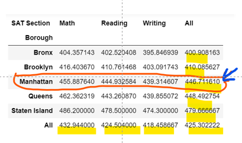

For example , The 446.711610 here , means that the Average **SAT Section** Score for all Manhattan schools is 446.711610

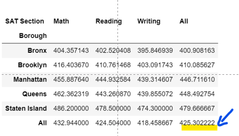

This is the intersection of all SAT Scores and Boroughs

```python
#calculate the max
sat.pivot_table('Score' , 'Borough' , 'SAT Section' , aggfunc = 'max' , margins = True)
```

| SAT Section Borough | Math | Reading | Writing | All |
| --- | --- | --- | --- | --- |
| Bronx | 714 | 672 | 672 | 714 |
| Brooklyn | 682 | 608 | 606 | 682 |
| Manhattan | 754 | 697 | 693 | 754 |
| Queens | 701 | 640 | 661 | 701 |
| Staten Island | 711 | 660 | 670 | 711 |
| All | 754 | 697 | 693 | 754 |

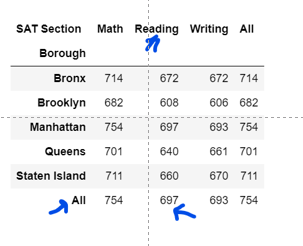

- This is how we interpret the "697" margin score
- 697 is the Maximum Reading Score ascross all Boroughs

If we want to change the "ALL" label to something meaningful or Descriptive

- We could do so using the "margins name" parameter
- In MS Excel , its usually reflected as "Grand Total"

```python
sat.pivot_table('Score' , 'Borough' , 'SAT Section' , aggfunc = 'max' , margins = True , margins_name = 'Grand Total')
```

| SAT Section Borough | Math | Reading | Writing | Grand Total |
| --- | --- | --- | --- | --- |
| Bronx | 714 | 672 | 672 | 714 |
| Brooklyn | 682 | 608 | 606 | 682 |
| Manhattan | 754 | 697 | 693 | 754 |
| Queens | 701 | 640 | 661 | 701 |
| Staten Island | 711 | 660 | 670 | 711 |
| Grand Total | 754 | 697 | 693 | 754 |

### MultiIndex Pivot Tables

```python
#pivot tables = groupby + agg + multiindex
```

pivot tables are a combination of group by + aggregate functions + hierarchical MultiIndex

#### How to leverage the nice index offered by pivot table : To create MultiIndex DataFrame

#### SAT Section Scores by School

```python
sat.pivot_table('Score' , 'School Name' , 'SAT Section')
```

| SAT Section School Name | Math | Reading | Writing |
| --- | --- | --- | --- |
| A. Philip Randolph Campus High School | 459 | 453 | 447 |
| ACORN Community High School | 379 | 395 | 385 |
| Abraham Lincoln High School | 441 | 422 | 422 |
| Academy for Careers in Television and Film | 444 | 458 | 444 |
| Academy for College Preparation and Career Exploration (College Board) | 386 | 397 | 393 |
| ... | ... | ... | ... |
| World Journalism Preparatory (College Board) | 484 | 491 | 487 |
| York Early College Academy | 496 | 481 | 473 |
| Young Women's Leadership School | 478 | 465 | 472 |
| Young Women's Leadership School in Astoria | 483 | 464 | 477 |
| Young Women's Leadership School in Queens | 415 | 420 | 433 |

375 rows × 3 columns

Lets say we want to squeeze in "Borough" into our Index and therefore create a MultiIndex.

- The above code can be modified as : #### sat.pivot_table('Score' , 'School Name' , 'SAT Section')

#### Syntax:

#### df.pivot_table(values = ' ', index = [ ' ' , ' ' ] , columns = ' ')

```python
sat.pivot_table('Score' , ['School Name' , 'Borough'], 'SAT Section')
```

| School Name | SAT Section Borough | Math | Reading | Writing |
| --- | --- | --- | --- | --- |
| A. Philip Randolph Campus High School | Manhattan | 459 | 453 | 447 |
| ACORN Community High School | Brooklyn | 379 | 395 | 385 |
| Abraham Lincoln High School | Brooklyn | 441 | 422 | 422 |
| Academy for Careers in Television and Film | Queens | 444 | 458 | 444 |
| Academy for College Preparation and Career Exploration (College Board) | Brooklyn | 386 | 397 | 393 |
| ... | ... | ... | ... | ... |
| World Journalism Preparatory (College Board) | Queens | 484 | 491 | 487 |
| York Early College Academy | Queens | 496 | 481 | 473 |
| Young Women's Leadership School | Manhattan | 478 | 465 | 472 |
| Young Women's Leadership School in Astoria | Queens | 483 | 464 | 477 |
| Young Women's Leadership School in Queens | Queens | 415 | 420 | 433 |

375 rows × 3 columns

```python
sat.pivot_table(values = 'Score' , index = ['School Name' , 'Borough'], columns = 'SAT Section')
```

| School Name | SAT Section Borough | Math | Reading | Writing |
| --- | --- | --- | --- | --- |
| A. Philip Randolph Campus High School | Manhattan | 459 | 453 | 447 |
| ACORN Community High School | Brooklyn | 379 | 395 | 385 |
| Abraham Lincoln High School | Brooklyn | 441 | 422 | 422 |
| Academy for Careers in Television and Film | Queens | 444 | 458 | 444 |
| Academy for College Preparation and Career Exploration (College Board) | Brooklyn | 386 | 397 | 393 |
| ... | ... | ... | ... | ... |
| World Journalism Preparatory (College Board) | Queens | 484 | 491 | 487 |
| York Early College Academy | Queens | 496 | 481 | 473 |
| Young Women's Leadership School | Manhattan | 478 | 465 | 472 |
| Young Women's Leadership School in Astoria | Queens | 483 | 464 | 477 |
| Young Women's Leadership School in Queens | Queens | 415 | 420 | 433 |

375 rows × 3 columns

If we want to move this MultiIndex from the Index dimension to our Column Axis , we just need to swap the parameters.

```python
sat.pivot_table(values = 'Score' , columns = ['School Name' , 'Borough'], index = 'SAT Section')
```

| School Name Borough SAT Section | A. Philip Randolph Campus High School Manhattan | ACORN Community High School Brooklyn | Abraham Lincoln High School Brooklyn | Academy for Careers in Television and Film Queens | Academy for College Preparation and Career Exploration (College Board) Brooklyn | Academy for Conservation and the Environment Brooklyn | Academy for Environmental Leadership Brooklyn | Academy for Health Careers Brooklyn | Academy for Language and Technology Bronx | Academy for Scholarship and Entrepreneurship (College Board) Bronx | ... | Williamsburg High School for Architecture and Design Brooklyn | Williamsburg Preparatory School Brooklyn | Wings Academy Bronx | Women's Academy of Excellence Bronx | World Academy for Total Community Health High School Brooklyn | World Journalism Preparatory (College Board) Queens | York Early College Academy Queens | Young Women's Leadership School Manhattan | Young Women's Leadership School in Astoria Queens | Young Women's Leadership School in Queens Queens |
| --- | --- | --- | --- | --- | --- | --- | --- | --- | --- | --- | --- | --- | --- | --- | --- | --- | --- | --- | --- | --- | --- |
| Math | 459 | 379 | 441 | 444 | 386 | 381 | 365 | 406 | 371 | 392 | ... | 415 | 443 | 379 | 386 | 380 | 484 | 496 | 478 | 483 | 415 |
| Reading | 453 | 395 | 422 | 458 | 397 | 397 | 366 | 405 | 334 | 408 | ... | 424 | 440 | 372 | 390 | 389 | 491 | 481 | 465 | 464 | 420 |
| Writing | 447 | 385 | 422 | 444 | 393 | 390 | 348 | 396 | 348 | 400 | ... | 407 | 430 | 373 | 389 | 384 | 487 | 473 | 472 | 477 | 433 |

3 rows × 375 columns

```python
#We can  switch multiindex to from index to column axis or vice versa by simply transposing
sat.pivot_table(values = 'Score' , columns = ['School Name' , 'Borough'], index = 'SAT Section').T
```

| School Name | SAT Section Borough | Math | Reading | Writing |
| --- | --- | --- | --- | --- |
| A. Philip Randolph Campus High School | Manhattan | 459 | 453 | 447 |
| ACORN Community High School | Brooklyn | 379 | 395 | 385 |
| Abraham Lincoln High School | Brooklyn | 441 | 422 | 422 |
| Academy for Careers in Television and Film | Queens | 444 | 458 | 444 |
| Academy for College Preparation and Career Exploration (College Board) | Brooklyn | 386 | 397 | 393 |
| ... | ... | ... | ... | ... |
| World Journalism Preparatory (College Board) | Queens | 484 | 491 | 487 |
| York Early College Academy | Queens | 496 | 481 | 473 |
| Young Women's Leadership School | Manhattan | 478 | 465 | 472 |
| Young Women's Leadership School in Astoria | Queens | 483 | 464 | 477 |
| Young Women's Leadership School in Queens | Queens | 415 | 420 | 433 |

375 rows × 3 columns

#### Takeaway:

Using Dataframe pivot tables we can create MultiIndex dataframes along both Axes simply by passing a list of labels instead of Single strings

### Applying Multiple Functions

#### previously

sat.pivot_table('Score' , 'Borough' , 'SAT Section' , aggfunc = 'max')

Often times it may be useful to apply several of these functions at once.

- We want to see min and max SAT Section Scores by Borough in one single pivot table.

#### Q. Show the min and max SAT Section scores by Borough

```python
sat.pivot_table('Score' , 'Borough' , 'SAT Section' , aggfunc = ['min' , 'max'])
```

| SAT Section Borough | min Math | min Reading | min Writing | max Math | max Reading | max Writing |
| --- | --- | --- | --- | --- | --- | --- |
| Bronx | 317 | 311 | 292 | 714 | 672 | 672 |
| Brooklyn | 319 | 302 | 284 | 682 | 608 | 606 |
| Manhattan | 344 | 330 | 316 | 754 | 697 | 693 |
| Queens | 340 | 320 | 318 | 701 | 640 | 661 |
| Staten Island | 420 | 427 | 409 | 711 | 660 | 670 |

```python
#We can rename the min and max labels
sat.pivot_table('Score' , 'Borough' , 'SAT Section' , aggfunc = ['min' , 'max'])\
                    .rename(axis =1, level=0 , mapper = {'min' : 'Min_SAT_Scores' , 'max' : 'MAX_SAT_Scores'})
```

| SAT Section Borough | Min_SAT_Scores Math | Min_SAT_Scores Reading | Min_SAT_Scores Writing | MAX_SAT_Scores Math | MAX_SAT_Scores Reading | MAX_SAT_Scores Writing |
| --- | --- | --- | --- | --- | --- | --- |
| Bronx | 317 | 311 | 292 | 714 | 672 | 672 |
| Brooklyn | 319 | 302 | 284 | 682 | 608 | 606 |
| Manhattan | 344 | 330 | 316 | 754 | 697 | 693 |
| Queens | 340 | 320 | 318 | 701 | 640 | 661 |
| Staten Island | 420 | 427 | 409 | 711 | 660 | 670 |

```python
mult = sat.pivot_table('Score' , 'Borough' , 'SAT Section' , aggfunc = ['min' , 'max'])\
                    .rename(axis =1, level=0 , mapper = {'min' : 'Min_SAT_Scores' , 'max' : 'MAX_SAT_Scores'})
```

```python
mult.columns
```

```
MultiIndex([('Min_SAT_Scores',    'Math'),
            ('Min_SAT_Scores', 'Reading'),
            ('Min_SAT_Scores', 'Writing'),
            ('MAX_SAT_Scores',    'Math'),
            ('MAX_SAT_Scores', 'Reading'),
            ('MAX_SAT_Scores', 'Writing')],
           names=[None, 'SAT Section'])
```

```python
#Indexing multiindex Columns
mult.loc[mult.MAX_SAT_Scores.Math >= 600]
```

| SAT Section Borough | Min_SAT_Scores Math | Min_SAT_Scores Reading | Min_SAT_Scores Writing | MAX_SAT_Scores Math | MAX_SAT_Scores Reading | MAX_SAT_Scores Writing |
| --- | --- | --- | --- | --- | --- | --- |
| Bronx | 317 | 311 | 292 | 714 | 672 | 672 |
| Brooklyn | 319 | 302 | 284 | 682 | 608 | 606 |
| Manhattan | 344 | 330 | 316 | 754 | 697 | 693 |
| Queens | 340 | 320 | 318 | 701 | 640 | 661 |
| Staten Island | 420 | 427 | 409 | 711 | 660 | 670 |

```python
mult.loc[mult.MAX_SAT_Scores.Math >= 600][['MAX_SAT_Scores']]
```

| SAT Section Borough | MAX_SAT_Scores Math | MAX_SAT_Scores Reading | MAX_SAT_Scores Writing |
| --- | --- | --- | --- |
| Bronx | 714 | 672 | 672 |
| Brooklyn | 682 | 608 | 606 |
| Manhattan | 754 | 697 | 693 |
| Queens | 701 | 640 | 661 |
| Staten Island | 711 | 660 | 670 |

### Skill challenge

Starting with our main Dataframe (sat) , create a pivot table that summarises the total student enrollment across all 5 Boroughs.

Which Boroughs have the highest and lowest High School Student Bodies?

```python
sat.head()
```

|  | School Name | Borough | Student Enrollment | Percent Tested | SAT Section | Score | SAT Takers |
| --- | --- | --- | --- | --- | --- | --- | --- |
| 0 | A. Philip Randolph Campus High School | Manhattan | 1354 | 74.0 | Math | 459 | 1001.960 |
| 1 | A. Philip Randolph Campus High School | Manhattan | 1354 | 74.0 | Reading | 453 | 1001.960 |
| 2 | A. Philip Randolph Campus High School | Manhattan | 1354 | 74.0 | Writing | 447 | 1001.960 |
| 3 | Abraham Lincoln High School | Brooklyn | 2341 | 54.9 | Math | 441 | 1285.209 |
| 4 | Abraham Lincoln High School | Brooklyn | 2341 | 54.9 | Reading | 422 | 1285.209 |

```python
sat.pivot_table(values = 'Student Enrollment' , index = 'Borough' , aggfunc = ['sum'])
```

| Borough | sum Student Enrollment |
| --- | --- |
| Bronx | 159267 |
| Brooklyn | 242814 |
| Manhattan | 170370 |
| Queens | 232437 |
| Staten Island | 55380 |

```python
sat.pivot_table(values = 'Student Enrollment' , index = 'Borough' , aggfunc = 'sum')
```

| Borough | Student Enrollment |
| --- | --- |
| Bronx | 159267 |
| Brooklyn | 242814 |
| Manhattan | 170370 |
| Queens | 232437 |
| Staten Island | 55380 |

```python
sat.pivot_table(values = 'Student Enrollment' , index = 'Borough' , aggfunc = 'sum').sort_values(by = 'Student Enrollment' ,ascending = False)
```

| Borough | Student Enrollment |
| --- | --- |
| Brooklyn | 242814 |
| Queens | 232437 |
| Manhattan | 170370 |
| Bronx | 159267 |
| Staten Island | 55380 |

### OR

```python
sat.pivot_table(values = 'Student Enrollment' , index = 'Borough' , aggfunc = 'sum').nlargest(5 ,columns = 'Student Enrollment')
```

| Borough | Student Enrollment |
| --- | --- |
| Brooklyn | 242814 |
| Queens | 232437 |
| Manhattan | 170370 |
| Bronx | 159267 |
| Staten Island | 55380 |

###### idxmin : gives us the smallest record

```python
sat.pivot_table(values = 'Student Enrollment' , index = 'Borough' , aggfunc = 'sum').idxmin()
```

```
Student Enrollment    Staten Island
dtype: object
```

```python
sat.pivot_table(values = 'Student Enrollment' , index = 'Borough' , aggfunc = 'sum').idxmax()
```

```
Student Enrollment    Brooklyn
dtype: object
```

###### idxmin : gives us the smallest record

```python
sat.pivot_table(values = 'Student Enrollment' , index = 'Borough' , aggfunc = 'sum').idxmin()
```

```
Student Enrollment    Staten Island
dtype: object
```

#### Modify the Pivot table from the Step above to also reflec the Average Student body size (Student Enrollment), across Boroughs in the same pivot table

```python
sat.pivot_table(values = 'Student Enrollment' , index = 'Borough' , aggfunc = ['sum' , 'mean'])
```

| Borough | sum Student Enrollment | mean Student Enrollment |
| --- | --- | --- |
| Bronx | 159267 | 541.724490 |
| Brooklyn | 242814 | 742.550459 |
| Manhattan | 170370 | 638.089888 |
| Queens | 232437 | 1122.884058 |
| Staten Island | 55380 | 1846.000000 |

#### Create a pivot table of high Schools from the Queens Borough (Borough) , containing the SAT Section Scores (SAT Section , Score) as columns and the School Name as Index. Sort the table in Descending order by math Section scores

```python
sat.head(4)
```

|  | School Name | Borough | Student Enrollment | Percent Tested | SAT Section | Score | SAT Takers |
| --- | --- | --- | --- | --- | --- | --- | --- |
| 0 | A. Philip Randolph Campus High School | Manhattan | 1354 | 74.0 | Math | 459 | 1001.960 |
| 1 | A. Philip Randolph Campus High School | Manhattan | 1354 | 74.0 | Reading | 453 | 1001.960 |
| 2 | A. Philip Randolph Campus High School | Manhattan | 1354 | 74.0 | Writing | 447 | 1001.960 |
| 3 | Abraham Lincoln High School | Brooklyn | 2341 | 54.9 | Math | 441 | 1285.209 |

```python
sat.Borough.unique()
```

```
array(['Manhattan', 'Brooklyn', 'Queens', 'Bronx', 'Staten Island'],
      dtype=object)
```

```python
queens = sat[sat.Borough == 'Queens']
```

```python
queens.head()
```

|  | School Name | Borough | Student Enrollment | Percent Tested | SAT Section | Score | SAT Takers |
| --- | --- | --- | --- | --- | --- | --- | --- |
| 6 | Academy for Careers in Television and Film | Queens | 515 | 95.0 | Math | 444 | 489.250 |
| 7 | Academy for Careers in Television and Film | Queens | 515 | 95.0 | Reading | 458 | 489.250 |
| 8 | Academy for Careers in Television and Film | Queens | 515 | 95.0 | Writing | 444 | 489.250 |
| 33 | Academy of American Studies | Queens | 874 | 84.8 | Math | 495 | 741.152 |
| 34 | Academy of American Studies | Queens | 874 | 84.8 | Reading | 482 | 741.152 |

```python
queens.pivot_table(values = 'Score' , columns = ['SAT Section'] , index = 'School Name')
```

| SAT Section School Name | Math | Reading | Writing |
| --- | --- | --- | --- |
| Academy for Careers in Television and Film | 444 | 458 | 444 |
| Academy of American Studies | 495 | 482 | 479 |
| Academy of Finance and Enterprise | 489 | 456 | 459 |
| Academy of Medical Technology (College Board) | 422 | 424 | 415 |
| August Martin High School | 366 | 372 | 364 |
| ... | ... | ... | ... |
| William Cullen Bryant High School | 466 | 424 | 426 |
| World Journalism Preparatory (College Board) | 484 | 491 | 487 |
| York Early College Academy | 496 | 481 | 473 |
| Young Women's Leadership School in Astoria | 483 | 464 | 477 |
| Young Women's Leadership School in Queens | 415 | 420 | 433 |

69 rows × 3 columns

```python
queens.pivot_table(values = 'Score' , columns = ['SAT Section'] , index = 'School Name').sort_values(by ='Math' , ascending = False)
```

| SAT Section School Name | Math | Reading | Writing |
| --- | --- | --- | --- |
| Queens High School for the Sciences at York College | 701 | 621 | 625 |
| Townsend Harris High School | 680 | 640 | 661 |
| Baccalaureate School for Global Education | 633 | 620 | 628 |
| Bard High School Early College Queens | 631 | 598 | 610 |
| Scholars' Academy | 588 | 560 | 568 |
| ... | ... | ... | ... |
| Middle College High School at LaGuardia Community College | 377 | 389 | 377 |
| Queens High School for Information, Research, and Technology | 372 | 362 | 352 |
| August Martin High School | 366 | 372 | 364 |
| Rockaway Park High School for Environmental Sustainability | 357 | 381 | 376 |
| Pan American International High School | 340 | 320 | 318 |

69 rows × 3 columns

❤❤🧡💛💛💚❤❤🧡💛💛💚❤❤🧡💛💛💚❤❤🧡💛💛💚❤❤🧡💛💛💚❤❤🧡💛💛💚❤❤🧡💛💛💚❤❤🧡💛💛💚